# Project 7: Difference-in-Differences and Synthetic Control

Group Members: Yael, Anthony, Renata and Hero

```r
#.libPaths("C:/Program Files/R/R-4.0.5/library")
# Install and load packages
if (!require("pacman")) install.packages("pacman")
devtools::install_github("ebenmichael/augsynth")
```

```r
pacman::p_load(# Tidyverse packages including dplyr and ggplot2
               tidyverse,
               ggthemes,
               augsynth,
               gsynth)

# set seed
set.seed(1)

# load data
medicaid_expansion <- read_csv('medicaid_expansion.csv')
```

# Introduction

For this project, you will explore the question of whether the Affordable Care Act increased health insurance coverage (or conversely, decreased the number of people who are uninsured). The ACA was passed in March 2010, but several of its provisions were phased in over a few years. The ACA instituted the “individual mandate” which required that all Americans must carry health insurance, or else suffer a tax penalty. There are four mechanisms for how the ACA aims to reduce the uninsured population:

- Require companies with more than 50 employees to provide health insurance.
- Build state-run healthcare markets (“exchanges”) for individuals to purchase health insurance.
- Provide subsidies to middle income individuals and families who do not qualify for employer based coverage.
- Expand Medicaid to require that states grant eligibility to all citizens and legal residents earning up to 138% of the federal poverty line. The federal government would initially pay 100% of the costs of this expansion, and over a period of 5 years the burden would shift so the federal government would pay 90% and the states would pay 10%.

In 2012, the Supreme Court heard the landmark case NFIB v. Sebelius, which principally challenged the constitutionality of the law under the theory that Congress could not institute an individual mandate. The Supreme Court ultimately upheld the individual mandate under Congress’s taxation power, but struck down the requirement that states must expand Medicaid as impermissible subordination of the states to the federal government. Subsequently, several states refused to expand Medicaid when the program began on January 1, 2014. This refusal created the “Medicaid coverage gap” where there are indivudals who earn too much to qualify for Medicaid under the old standards, but too little to qualify for the ACA subsidies targeted at middle-income individuals.

States that refused to expand Medicaid principally cited the cost as the primary factor. Critics pointed out however, that the decision not to expand primarily broke down along partisan lines. In the years since the initial expansion, several states have opted into the program, either because of a change in the governing party, or because voters directly approved expansion via a ballot initiative.

You will explore the question of whether Medicaid expansion reduced the uninsured population in the U.S. in the 7 years since it went into effect. To address this question, you will use difference-in-differences estimation, and synthetic control.

# Data

The dataset you will work with has been assembled from a few different sources about Medicaid. The key variables are:

- **State**: Full name of state
- **Medicaid Expansion Adoption**: Date that the state adopted the Medicaid expansion, if it did so.
- **Year**: Year of observation.
- **Uninsured rate**: State uninsured rate in that year.

# Exploratory Data Analysis

## Highest and Lowest Uninsurance Rates

The first plot shows the uninsurance rates across years for each state prior to 2014. The plot is hard to read because of the number of states displayed, but we see that there is a large range of uninsurance rates across states (from less than 5% uninsured to almost 25% uninsured) but not as much variation within states over time.

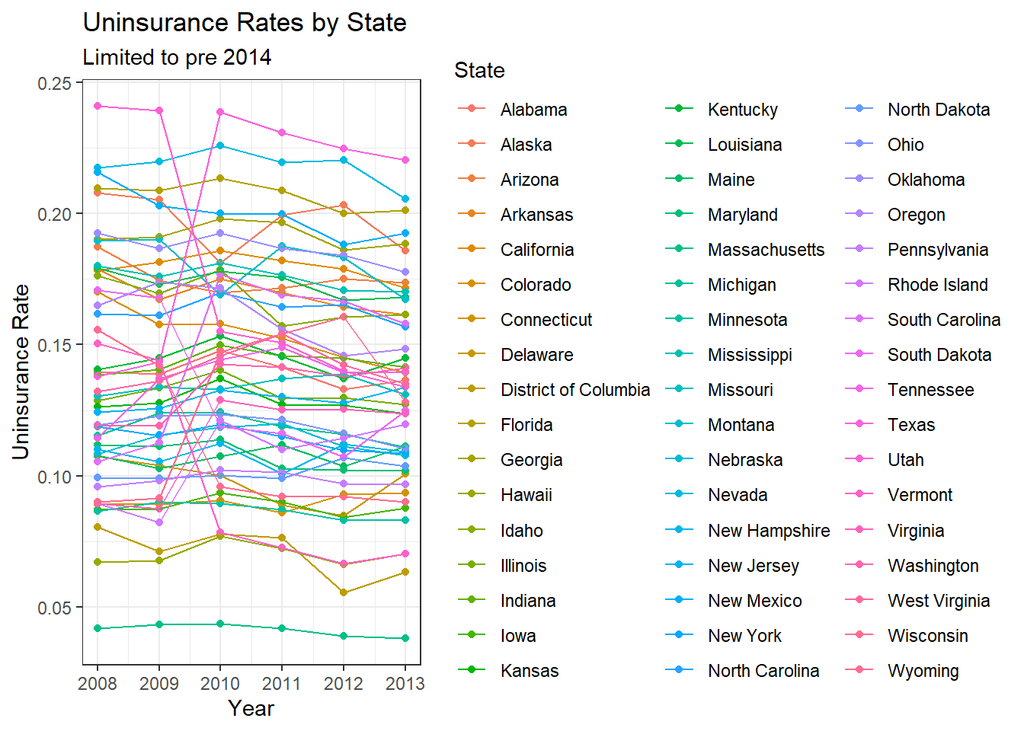

```r
# highest uninsured rates over time
medicaid_expansion %>%
  filter(year < 2014) %>%
  ggplot(aes(x = year, y = uninsured_rate, color = State)) +
  geom_point() +
  geom_line() +
  theme_bw() +
  labs(title = "Uninsurance Rates by State",
       subtitle = "Limited to pre 2014") +
  xlab("Year") +
  ylab("Uninsurance Rate")
```

To back out which states have the highest uninsurance rates over time, I first limit to the 10 states with the highest average uninsurance rates before 2014. We see from this plot below that Nevada has the most consistent high uninsurance rate. Utah starts higher but then decreased their uninsurance rate considerably in 2010 and Texas started low but then increased their’s to above Nevada’s in 2010.

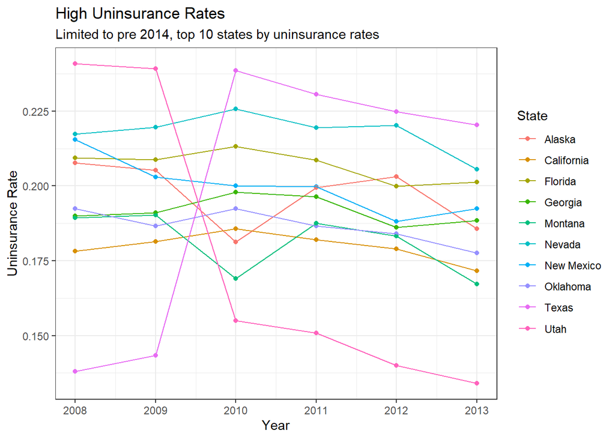

```r
medicaid_expansion %>%
  filter(year < 2014) %>%
  group_by(State) %>%
  mutate(mean = mean(uninsured_rate, na.rm = TRUE)) %>%
  arrange(-mean) %>%
  head(60) %>%
  ggplot(aes(x = year, y = uninsured_rate, color = State)) +
  geom_point() +
  geom_line() +
  theme_bw() +
  labs(title = "High Uninsurance Rates",
       subtitle = "Limited to pre 2014, top 10 states by uninsurance rates") +
  xlab("Year") +
  ylab("Uninsurance Rate")
```

We do the same for the states with the lowest uninsurance rates. Massachusetts has consistently the lowest uninsurance rate of all the states, considerably lower than the rest. This makes sense because the introduced Romney-Care before the ACA came into effect. Most states with low uninsurance rates are located in the north east.

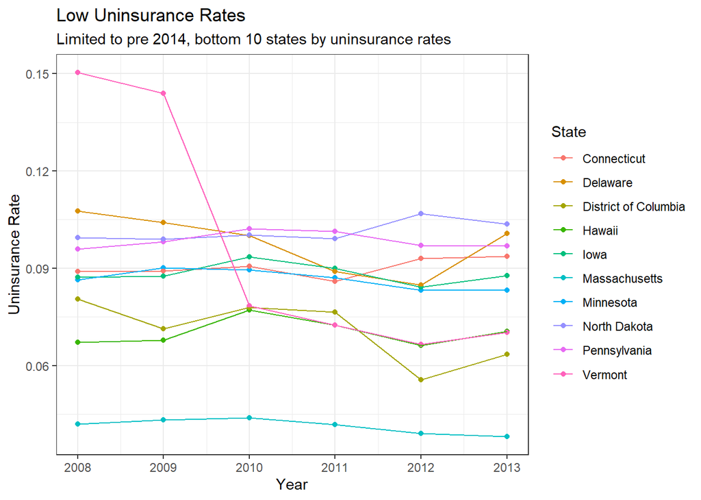

```r
medicaid_expansion %>%
  filter(year < 2014) %>%
  group_by(State) %>%
  mutate(mean = mean(uninsured_rate, na.rm = TRUE)) %>%
  arrange(mean) %>%
  head(60) %>%
  ggplot(aes(x = year, y = uninsured_rate, color = State)) +
  geom_point() +
  geom_line() +
  theme_bw() +
  labs(title = "Low Uninsurance Rates",
       subtitle = "Limited to pre 2014, bottom 10 states by uninsurance rates") +
  xlab("Year") +
  ylab("Uninsurance Rate")
```

## Most Uninsured People

The plot below shows the number of uninsured people in each state in the year before treatment (2013) and the last year in our data (2020). Even though California did not have one of the highest uninsurance rates, due to it’s population size, it has the most uninsured people of any state in 2013, followed by Texas. However, by 2020, California’s number of uninsured people had almost halved, due to its increase in insurance rate, however, Texas’s had only been reduced by about a million people, meaning it now has the most uninsured people in the country.

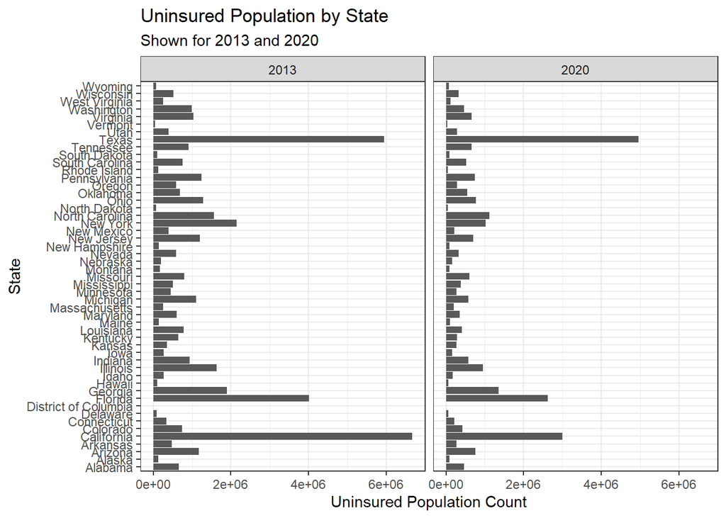

```r
medicaid_expansion%>%
  mutate(uninsured_pop = uninsured_rate*population)%>%
  filter(year == 2013 | year == 2020) %>%
  ggplot(aes(x = State, y = uninsured_pop)) +
  geom_col() +
  facet_wrap("year") +
  coord_flip() +
  theme_bw() +
  labs(title = "Uninsured Population by State",
       subtitle = "Shown for 2013 and 2020") +
  xlab("State") +
  ylab("Uninsured Population Count")
```

# Difference-in-Differences Estimation

## Estimate Model

Do the following:

- Choose a state that adopted the Medicaid expansion on January 1, 2014 and a state that did not. **Hint**: Do not pick Massachusetts as it passed a universal healthcare law in 2006, and also avoid picking a state that adopted the Medicaid expansion between 2014 and 2015.
- Assess the parallel trends assumption for your choices using a plot. If you are not satisfied that the assumption has been met, pick another state and try again (but detail the states you tried).

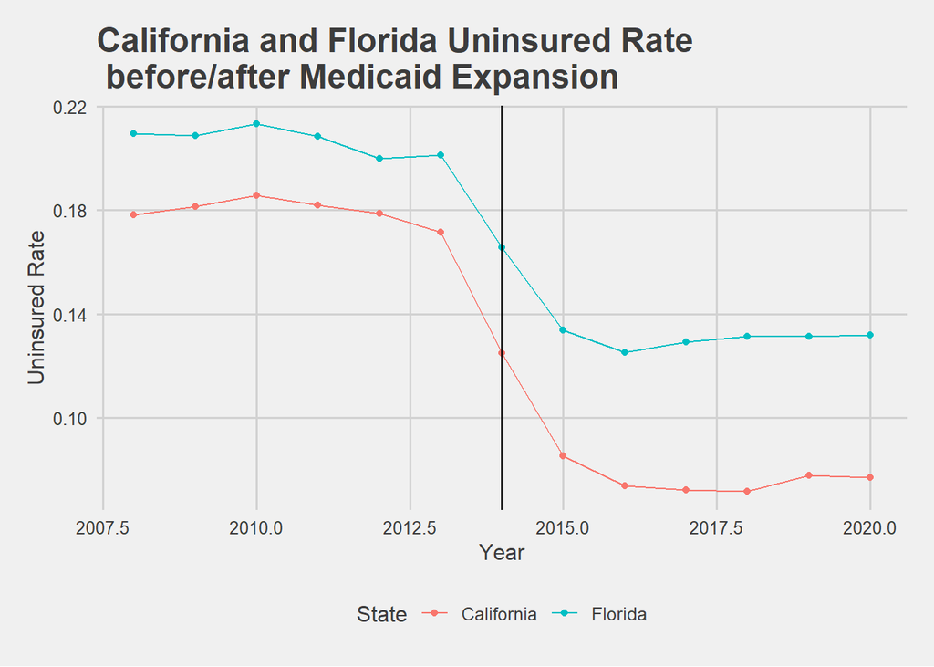

```r
# Parallel Trends plot

# I tried Texas, North Carolina, Georgia, Alabama, Wisconsin

medicaid_expansion %>%
  filter(State %in% c("California","Florida")) %>%
  ggplot() +
  geom_point(aes(x = year,
                 y = uninsured_rate,
                 color = State)) +
  geom_line(aes(x = year,
                y = uninsured_rate,
                color = State)) +
  geom_vline(aes(xintercept = 2014)) +
  theme_fivethirtyeight() +
  theme(axis.title = element_text()) +
  ggtitle('California and Florida Uninsured Rate \n before/after Medicaid Expansion') +
  xlab('Year') +
  ylab('Uninsured Rate')
```

- Estimates a difference-in-differences estimate of the effect of the Medicaid expansion on the uninsured share of the population. You may follow the lab example where we estimate the differences in one pre-treatment and one post-treatment period, or take an average of the pre-treatment and post-treatment outcomes

```r
# Difference-in-Differences estimation

# kansas-colorado
cf <- medicaid_expansion %>%
  filter(State %in% c("California","Florida")) %>%
  filter(year >= 2008 & year<= 2020)

# pre-treatment difference

pre_diff <- cf %>%
  filter(year == 2008) %>%
  select(State,
         uninsured_rate) %>%
  spread(State,
         uninsured_rate) %>%
  summarise(Florida - California)

# post-treatment difference

post_diff <- cf %>%
  filter(year == 2020) %>%
  select(State,
         uninsured_rate) %>%
  spread(State,
         uninsured_rate) %>%
  summarise(Florida - California)

# diff-in-diffs

diff_in_diffs <- post_diff - pre_diff
diff_in_diffs
```

```
##   Florida - California
## 1             0.023753
```

## Discussion Questions

- Card/Krueger’s original piece utilized the fact that towns on either side of the Delaware river are likely to be quite similar to one another in terms of demographics, economics, etc. Why is that intuition harder to replicate with this data?
- **Answer**: This intuition is a bit harder to replicate with this data because we are trying to compare states. Towns cover a much smaller geographic area, and thus, neighboring towns are likely similar geographically. Based on this, it is also likely they are similar in terms of demographics, economics, etc. States, however, can cover vast geographic areas and are likely very different from neighboring states.
- What are the strengths and weaknesses of using the parallel trends assumption in difference-in-differences estimates?
- **Answer**: The main strength of the parallel trends assumptions is its intuitiveness - it’s easily visualized. A weakness, however, is that there is no statistic we can use to determine if one comparison is truly better than another.

# Synthetic Control

Estimate Synthetic Control

Although several states did not expand Medicaid on January 1, 2014, many did later on. In some cases, a Democratic governor was elected and pushed for a state budget that included the Medicaid expansion, whereas in others voters approved expansion via a ballot initiative. The 2018 election was a watershed moment where several Republican-leaning states elected Democratic governors and approved Medicaid expansion. In cases with a ballot initiative, the state legislature and governor still must implement the results via legislation. For instance, Idaho voters approved a Medicaid expansion in the 2018 election, but it was not implemented in the state budget until late 2019, with enrollment beginning in 2020.

Do the following:

- Choose a state that adopted the Medicaid expansion after January 1, 2014. Construct a non-augmented synthetic control and plot the results (both pre-treatment fit and post-treatment differences). Also report the average ATT and L2 imbalance.

```r
syn_cal = medicaid_expansion %>%
  mutate(year_adopted = format(Date_Adopted, format="%Y"),
         adopted = if_else(year_adopted<=year,1,0),
         adopted2 = if_else(is.na(adopted),0,adopted),
         treated=if_else(State=="California" &adopted2==1 ,1,0))%>%                               # filter(Date_Adopted=="2014-01-01" | is.na(Date_Adopted))
  filter(State=="California" | is.na(Date_Adopted))


# non-augmented synthetic control
syn <- augsynth(uninsured_rate ~ treated, State, year, syn_cal,
                progfunc = "None", scm = T)

summary(syn)
```

```
##
## Call:
## single_augsynth(form = form, unit = !!enquo(unit), time = !!enquo(time),
##     t_int = t_int, data = data, progfunc = "None", scm = ..2)
##
## Average ATT Estimate (p Value for Joint Null):  -0.051   ( 0.318 )
## L2 Imbalance: 0.003
## Percent improvement from uniform weights: 95.5%
##
## Avg Estimated Bias: NA
##
## Inference type: Conformal inference
##
##  Time Estimate 95% CI Lower Bound 95% CI Upper Bound p Value
##  2014   -0.023             -0.127              0.081   0.143
##  2015   -0.048             -0.151              0.056   0.143
##  2016   -0.053             -0.157              0.051   0.143
##  2017   -0.057             -0.161              0.047   0.143
##  2018   -0.057             -0.161              0.046   0.143
##  2019   -0.060             -0.164              0.044   0.143
##  2020   -0.056             -0.160              0.048   0.143
```

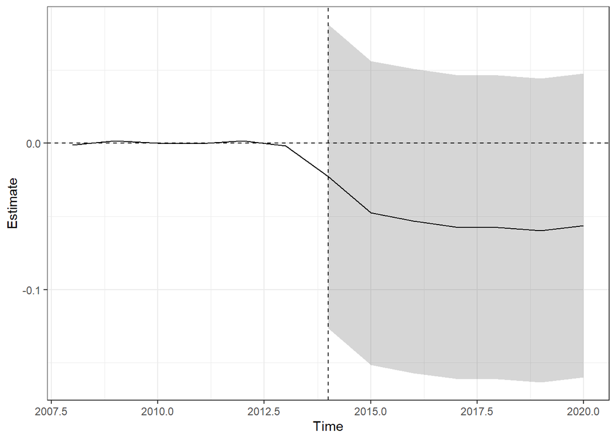

```r
plot(syn)
```

We can see which donors contributed the most to the synthetic California:

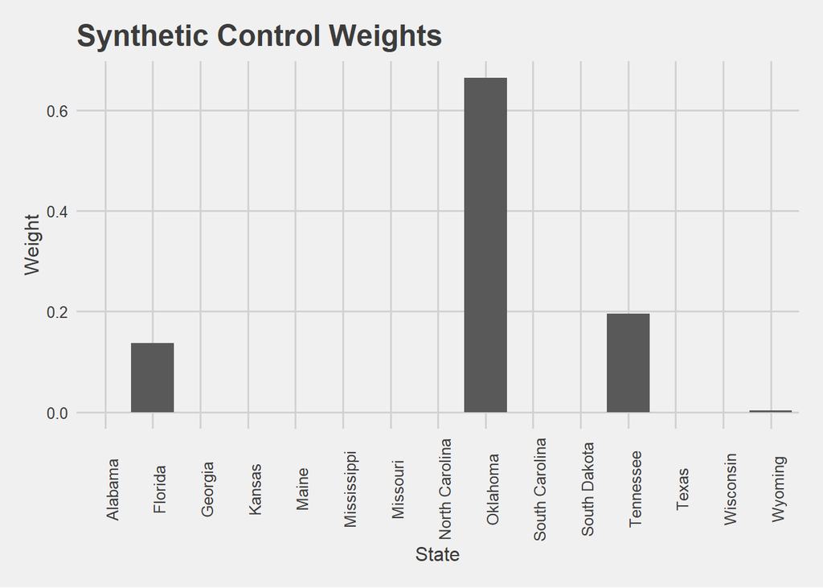

```r
# Convert weights to dataframe
data.frame(syn$weights) %>%
  # change index to a column
  tibble::rownames_to_column('State') %>%
  ggplot() +
  # stat = identity to take the literal value instead of a count for geom_bar()
  geom_bar(aes(x = State,
               y = syn.weights),
           stat = 'identity') +
  theme_fivethirtyeight() +
  theme(axis.title = element_text(),
        axis.text.x = element_text(angle = 90)) +
  ggtitle('Synthetic Control Weights') +
  xlab('State') +
  ylab('Weight')
```

[figure not shown]

```r
data.frame(syn$weights) %>%
  tibble::rownames_to_column('State') %>%
  filter(syn.weights > 0.00) %>%
  ggplot() +
  geom_bar(aes(x = State,
               y = syn.weights),
           stat = 'identity') +
  theme_fivethirtyeight() +
  theme(axis.title = element_text(),
        axis.text.x = element_text(angle = 90)) +
  ggtitle('Synthetic Control Weights>0.01') +
  xlab('State') +
  ylab('Weight')
```

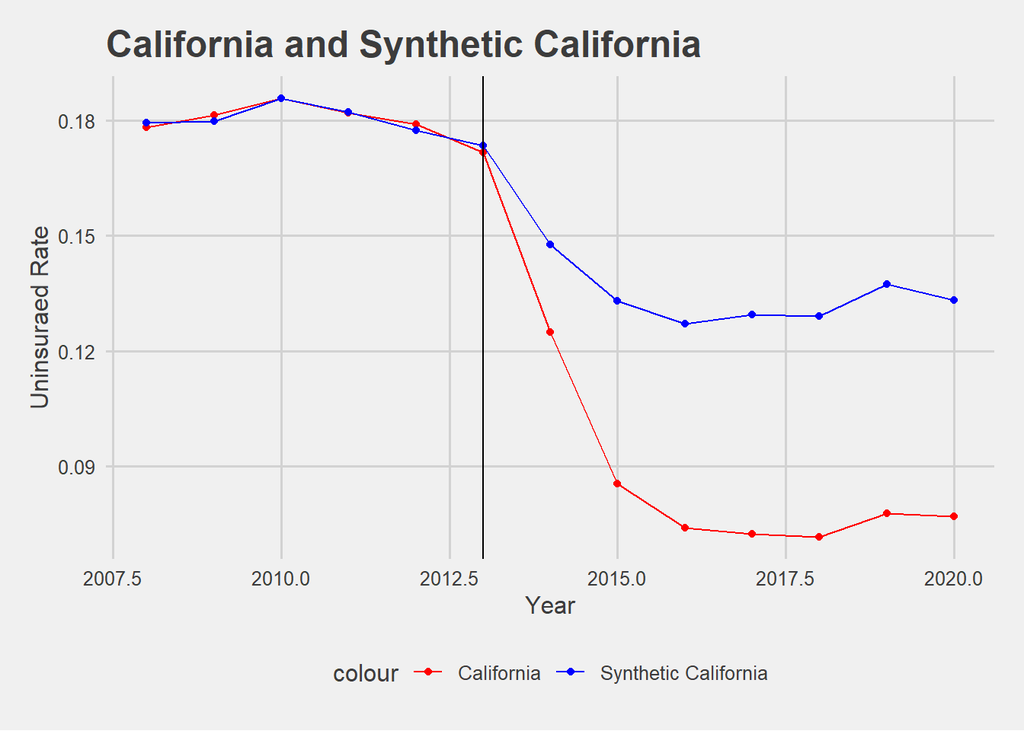

```r
# Aniket's method for getting the underlying data
syn_sum <- summary(syn)

cal_syn_cal <- syn_cal %>%
  filter(State == "California") %>%
  bind_cols(difference = syn_sum$att$Estimate) %>%
  mutate(synthetic_Cal = uninsured_rate - difference)

# Plot

cal_syn_cal %>%
  ggplot() +
  geom_point(aes(x = year,
                 y = uninsured_rate,
                 color = 'California')) +
  geom_line(aes(x = year,
                y = uninsured_rate,
                color = 'California')) +
  geom_point(aes(x = year,
                 y = synthetic_Cal,
                 color = 'Synthetic California')) +
  geom_line(aes(x = year,
                y = synthetic_Cal,
                color = 'Synthetic California')) +
  scale_color_manual(values = c('California' = 'red', 'Synthetic California' = 'blue')) +
  geom_vline(aes(xintercept = 2013)) +
  theme_fivethirtyeight() +
  theme(axis.title = element_text()) +
  ggtitle('California and Synthetic California') +
  xlab('Year') +
  ylab('Uninsuraed Rate')
```

- Re-run the same analysis but this time use an augmentation (default choices are Ridge, Matrix Completion, and GSynth). Create the same plot and report the average ATT and L2 imbalance.

```r
# augmented synthetic control
ridge_syn <- augsynth(uninsured_rate ~ treated, State, year, syn_cal,
                progfunc = "ridge", scm = T)

summary(ridge_syn)
```

```
##
## Call:
## single_augsynth(form = form, unit = !!enquo(unit), time = !!enquo(time),
##     t_int = t_int, data = data, progfunc = "ridge", scm = ..2)
##
## Average ATT Estimate (p Value for Joint Null):  -0.051   ( 0.406 )
## L2 Imbalance: 0.003
## Percent improvement from uniform weights: 95.5%
##
## Avg Estimated Bias: 0.000
##
## Inference type: Conformal inference
##
##  Time Estimate 95% CI Lower Bound 95% CI Upper Bound p Value
##  2014   -0.023             -0.127              0.081   0.143
##  2015   -0.048             -0.151              0.056   0.143
##  2016   -0.053             -0.157              0.051   0.143
##  2017   -0.057             -0.161              0.047   0.143
##  2018   -0.057             -0.161              0.046   0.143
##  2019   -0.060             -0.164              0.044   0.143
##  2020   -0.056             -0.160              0.048   0.143
```

- Plot barplots to visualize the weights of the donors.

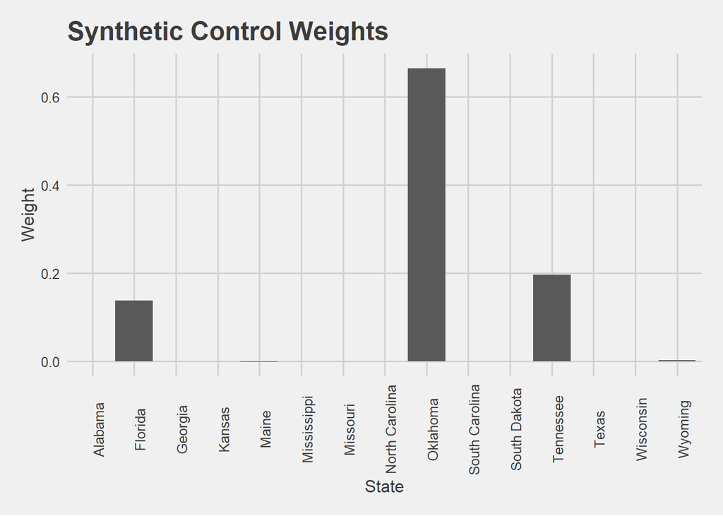

```r
# Convert weights to dataframe
data.frame(ridge_syn$weights) %>%
  tibble::rownames_to_column('State') %>%
  ggplot() +
  geom_bar(aes(x = State, y = ridge_syn.weights),
           stat = 'identity') +
  theme_fivethirtyeight() +
  theme(axis.title = element_text(),
        axis.text.x = element_text(angle = 90)) +
  ggtitle('Synthetic Control Weights') +
  xlab('State') +
  ylab('Weight')
```

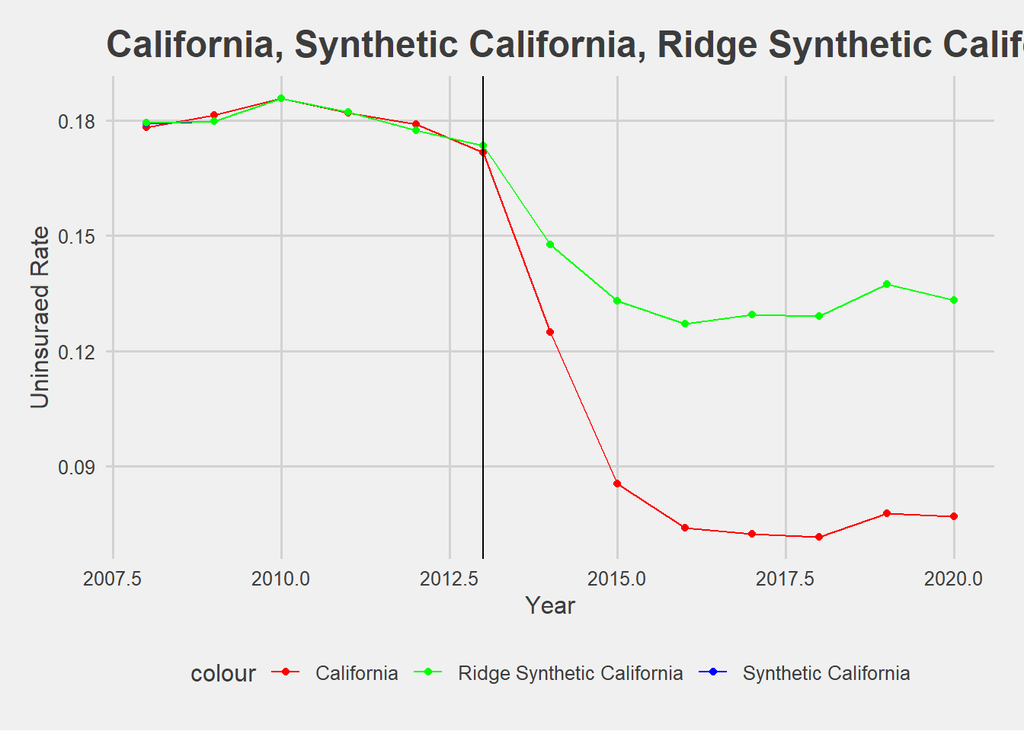

```r
# Aniket's method for getting the underlying data
ridge_sum <- summary(ridge_syn)

Cal_synCal_ridgesynCal <- cal_syn_cal %>%
  bind_cols(ridge_difference = ridge_sum$att$Estimate) %>%
  mutate(ridge_synthetic_Cal = uninsured_rate - ridge_difference)

Cal_synCal_ridgesynCal %>%
  ggplot() +
  geom_point(aes(x = year,
                 y = uninsured_rate,
                 color = 'California')) +
  geom_line(aes(x = year,
                y = uninsured_rate,
                color = 'California')) +
  geom_point(aes(x = year,
                 y = synthetic_Cal,
                 color = 'Synthetic California')) +
  geom_line(aes(x = year,
                y = synthetic_Cal,
                color = 'Synthetic California')) +
  geom_point(aes(x = year,
                 y = ridge_synthetic_Cal,
                 color = 'Ridge Synthetic California')) +
  geom_line(aes(x = year,
                y = ridge_synthetic_Cal,
                color = 'Ridge Synthetic California')) +
  scale_color_manual(values = c('California' = 'red',
                                'Synthetic California' = 'blue',
                                'Ridge Synthetic California' = 'green')) +
  geom_vline(aes(xintercept = 2013)) +
  theme_fivethirtyeight() +
  theme(axis.title = element_text()) +
  ggtitle('California, Synthetic California, Ridge Synthetic California') +
  xlab('Year') +
  ylab('Uninsuraed Rate')
```

**HINT**: Is there any preprocessing you need to do before you allow the program to automatically find weights for donor states?

## Discussion Questions

- What are the advantages and disadvantages of synthetic control compared to difference-in-differences estimators?
- **Answer**: In comparison with Diff-in-Diff, synthetic control estimators have the advantage of automatically calculating the weights for the pre-treatment and counterfactual estimate, so that we don’t need to have an assumption of a parallel trend as we had with Diff-in-Diff. At the same time, the use of many controls may not neccessarily be beneficial, and can lead to more bias by averaging the effect.
- One of the benefits of synthetic control is that the weights are bounded between [0,1] and the weights must sum to 1. Augmentation might relax this assumption by allowing for negative weights. Does this create an interpretation problem, and how should we balance this consideration against the improvements augmentation offers in terms of imbalance in the pre-treatment period?
- **Answer**:

# Staggered Adoption Synthetic Control

## Estimate Multisynth

In the synthetic control model above, we limited our donor pool to states that never adopted Medicaid expansion, so that we can estimate the ATE for the effect of introducing Medicaid expansion relative to not having Medicaid expansion. This limits us to estimating the effect of Medicaid expansion for California. However, we might want to estimate the effect overall, using all possible states as treatment when they do adopt Medicaid expansion. To do this, we have use a staggered adoption synthetic control model.

**Multisynth Model with Individual States**

We first fit a model that estimates a separate synthetic control for each treated state, and then averages the ATEs from each state.

```r
# multisynth model states
mult_d <- medicaid_expansion %>%
  mutate(year_adopted = format(Date_Adopted, "%Y"),
         treated = case_when(year >= year_adopted ~ 1,
                             year < year_adopted ~ 0,
                             TRUE ~ 0)) %>%
  # drop MA b/c they always had a version of Medicaid expansion
  filter(State != "Massachusetts")

multsyn_state <- multisynth(uninsured_rate ~ treated,
                            unit = State,
                            time = year,
                            data = mult_d,
                            nu = 0,
                            n_leads = 10)

summary(multsyn_state)
```

```
##
## Call:
## multisynth(form = uninsured_rate ~ treated, unit = State, time = year,
##     data = mult_d, n_leads = 10, nu = 0)
##
## Average ATT Estimate (Std. Error): -0.018  (0.006)
##
## Global L2 Imbalance: 0.001
## Scaled Global L2 Imbalance: 0.049
## Percent improvement from uniform global weights: 95.1
##
## Individual L2 Imbalance: 0.005
## Scaled Individual L2 Imbalance: 0.105
## Percent improvement from uniform individual weights: 89.5
##
##  Time Since Treatment   Level    Estimate   Std.Error lower_bound  upper_bound
##                     0 Average -0.01156346 0.004675468 -0.02074648 -0.002715116
##                     1 Average -0.01833782 0.006304120 -0.03136480 -0.006726967
##                     2 Average -0.01780188 0.006564310 -0.03078581 -0.004926073
##                     3 Average -0.02007658 0.006862464 -0.03397658 -0.007241808
##                     4 Average -0.02138186 0.006625143 -0.03475021 -0.008893011
##                     5 Average -0.02082117 0.006410664 -0.03334404 -0.008736767
##                     6 Average -0.02054416 0.006960002 -0.03428981 -0.007703554
```

The multisynth model used above estimates a significant ATE of -0.018. We estimate the ATE for the maximum number of years post-treatment and see that the effect actually gets larger over time (though levels off 5/6 years after treatment).

The plot below shows the ATE for the 5 states with the highest ATE, the 5 states with the lowest ATE and the average across all states.

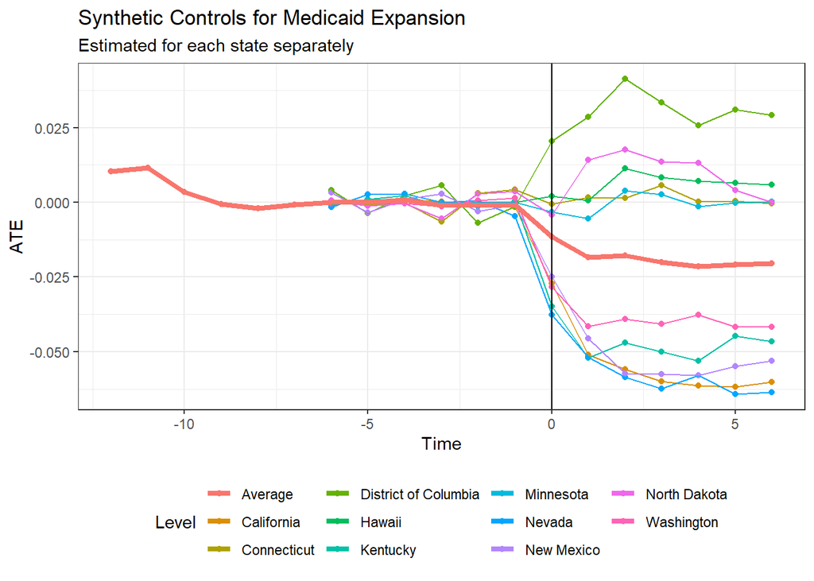

```r
mult_state_sum <- summary(multsyn_state)

high5 <- mult_state_sum$att %>%
  filter(is.na(Time)) %>%
  arrange(Estimate) %>%
  head(5) %>%
  select(Level) %>% pull()

low5 <-  mult_state_sum$att %>%
  filter(is.na(Time)) %>%
  arrange(Estimate) %>%
  tail(5) %>%
  select(Level) %>% pull()

mult_state_sum$att %>%
  filter(Level %in% c("Average", low5, high5)) %>%
  filter(!is.na(Time) & !is.na(Estimate)) %>%
  ggplot(aes(x = Time, y = Estimate, color = Level)) +
  geom_point() +
  geom_line() +
  geom_line(data = filter(mult_state_sum$att, Level == "Average"), aes(x = Time, y = Estimate), size = 1.5) +
  geom_vline(xintercept = 0) +
  theme_bw() +
  theme(axis.title = element_text(),
        legend.position = "bottom") +
  labs(title = 'Synthetic Controls for Medicaid Expansion',
       subtitle = "Estimated for each state separately"  ) +
  xlab('Time') +
  ylab('ATE')
```

**Multisynth Model using Time Cohorts**

Now, instead of constructing synthetic controls for each state, we pool states based on their year of adoption and create synthetic control for each time cohort.

```r
# multisynth model time cohorts
multsyn_time <- multisynth(uninsured_rate ~ treated,
                            unit = State,
                            time = year,
                            data = mult_d,
                            nu = 1,
                            n_leads = 10)

summary(multsyn_time)
```

```
##
## Call:
## multisynth(form = uninsured_rate ~ treated, unit = State, time = year,
##     data = mult_d, n_leads = 10, nu = 1)
##
## Average ATT Estimate (Std. Error): -0.014  (0.006)
##
## Global L2 Imbalance: 0.000
## Scaled Global L2 Imbalance: 0.000
## Percent improvement from uniform global weights: 100
##
## Individual L2 Imbalance: 0.010
## Scaled Individual L2 Imbalance: 0.232
## Percent improvement from uniform individual weights: 76.8
##
##  Time Since Treatment   Level     Estimate   Std.Error lower_bound  upper_bound
##                     0 Average -0.009051383 0.004250358 -0.01718638 -0.001232664
##                     1 Average -0.014453023 0.006082836 -0.02667609 -0.002734576
##                     2 Average -0.013635159 0.006338161 -0.02612963 -0.001346461
##                     3 Average -0.016917639 0.006557016 -0.02949312 -0.004891058
##                     4 Average -0.017977900 0.006385714 -0.02999995 -0.006464850
##                     5 Average -0.015459962 0.006673219 -0.02834409 -0.002459548
##                     6 Average -0.015557549 0.007007772 -0.02892730 -0.002049729
```

The plot below shows the ATE estimated for each state based on the synthetic control for that state’s time cohort. The average is still negative, but it is a smaller magnitude than the ATE estimated from the individual states synthetic controls above. There is overlap in the states with the most positive ATE (meaning their uninsurance rate actually increased after adoption) between the time cohort method and the individual state method. Likewise, for the states with the most negative ATE.

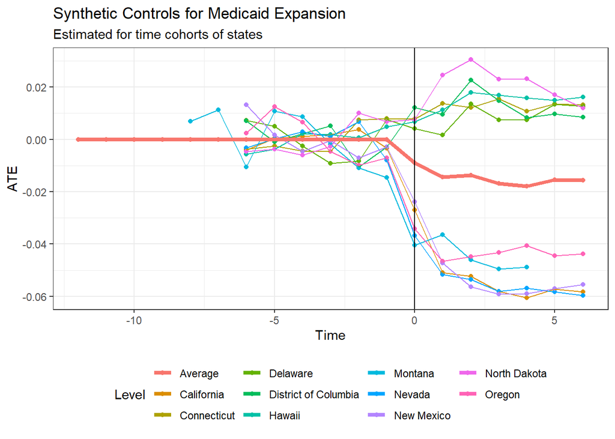

```r
mult_time_sum <- summary(multsyn_time)

high5 <- mult_time_sum$att %>%
  filter(is.na(Time)) %>%
  arrange(Estimate) %>%
  head(5) %>%
  select(Level) %>% pull()

low5 <-  mult_time_sum$att %>%
  filter(is.na(Time)) %>%
  arrange(Estimate) %>%
  tail(5) %>%
  select(Level) %>% pull()

mult_time_sum$att %>%
  filter(Level %in% c("Average", low5, high5)) %>%
  filter(!is.na(Time) & !is.na(Estimate)) %>%
  ggplot(aes(x = Time, y = Estimate, color = Level)) +
  geom_point() +
  geom_line() +
  geom_line(data = filter(mult_time_sum$att, Level == "Average"), aes(x = Time, y = Estimate), size = 1.5) +
  geom_vline(xintercept = 0) +
  theme_bw() +
  theme(axis.title = element_text(),
        legend.position = "bottom") +
  labs(title = 'Synthetic Controls for Medicaid Expansion',
       subtitle = "Estimated for time cohorts of states"  ) +
  xlab('Time') +
  ylab('ATE')
```

## Staggered Adoption Discussion Questions

*One feature of Medicaid is that it is jointly administered by the federal government and the states, and states have some flexibility in how they implement Medicaid. For example, during the Trump administration, several states applied for waivers where they could add work requirements to the eligibility standards (i.e. an individual needed to work for 80 hours/month to qualify for Medicaid). Given these differences, do you see evidence for the idea that different states had different treatment effect sizes?*

**Answer**: We see evidence that states had different treatment effect sizes. Even though the average ATE is negative, states range in the average ATE over the whole time period from -0.0566 to 0.0299 (using the estimates from the separate state model). This means that some states actually increased the share of uninsured persons when they adopted Medicaid. This could be explained by the work requirements they put in place, which block people from accessing Medicaid.

*Do you see evidence for the idea that early adopters of Medicaid expansion enjoyed a larger decrease in the uninsured population?*

[figure not shown]

# General Discussion Questions

- Why are DiD and synthetic control estimates well suited to studies of aggregated units like cities, states, countries, etc?
- **Answer**:
- What role does selection into treatment play in DiD/synthetic control versus regression discontinuity? When would we want to use either method?
- **Answer**: